# PHQ-9 憂鬱分數的廣義線性模型（GLM）分析報告

NHANES 資料（n = 3,044）

Published

October 21, 2026

```r
dat <- read.csv("nhanes_data.csv", stringsAsFactors = FALSE)

# 類別變數轉為因子並指定參照組
dat <- dat %>% mutate(
  gender = factor(gender, levels = c("Female", "Male")),
  race = factor(race, levels = c("Non-Hispanic White", "Non-Hispanic Black", "Non-Hispanic Asian",
                                 "Mexican American", "Other Hispanic", "Other/Multi-Racial")),
  education = factor(education, levels = c("Less than 9th grade", "9-11th grade", "High school",
                                           "Some college", "College graduate")),
  smoking_status = factor(smoking_status, levels = c("Never", "Former", "Current"))
)
num_vars <- c("age", "income_ratio", "bmi", "hba1c", "sleep_hours")
cat_vars <- c("gender", "race", "education", "smoking_status",
              "diabetes", "exercise", "hypertension", "trouble_sleeping")
```

# 1 變數清單與分析設定

```r
raw <- read.csv("nhanes_data.csv", stringsAsFactors = FALSE)
var_tbl <- data.frame(
  變數名稱 = names(raw),
  資料型態 = sapply(raw, function(x) class(x)[1]),
  相異值個數 = sapply(raw, function(x) length(unique(x))),
  遺漏值個數 = sapply(raw, function(x) sum(is.na(x))),
  範例值 = sapply(raw, function(x) paste(head(unique(x), 3), collapse = ", ")),
  row.names = NULL
)
kable(var_tbl)
```

Table 1: 資料中的所有變數

| 變數名稱 | 資料型態 | 相異值個數 | 遺漏值個數 | 範例值 |
| --- | --- | --- | --- | --- |
| age | integer | 46 | 0 | 56, 54, 61 |
| gender | character | 2 | 0 | Male, Female |
| race | character | 6 | 0 | Non-Hispanic Asian, Non-Hispanic Black, Non-Hispanic White |
| education | character | 5 | 0 | College graduate, Some college, High school |
| income_ratio | numeric | 404 | 0 | 5, 1.86, 1.49 |
| cluster_id | character | 30 | 0 | C134_2, C147_1, C143_1 |
| diabetes | integer | 2 | 0 | 0, 1 |
| bmi | numeric | 373 | 0 | 21.3, 39.9, 30.7 |
| hba1c | numeric | 87 | 0 | 5.7, 12.7, 5.6 |
| phq9_score | integer | 26 | 0 | 2, 5, 0 |
| exercise | integer | 2 | 0 | 1, 0 |
| smoking_status | character | 3 | 0 | Never, Former, Current |
| hypertension | integer | 2 | 0 | 0, 1 |
| sleep_hours | numeric | 23 | 0 | 7, 8, 9 |
| trouble_sleeping | integer | 2 | 0 | 1, 0 |

資料共 3,044 筆、15 個變數（Table 1），經使用者確認的分析設定如下：

- **研究目的**：解釋關聯。本報告只描述變數之間的關聯，不做因果推論。
- **反應變數（Y）**：`phq9_score`，PHQ-9 憂鬱量表總分（0–27 分）。
- **解釋變數（X）**：age、gender、race、education、income_ratio、diabetes、bmi、hba1c、exercise、smoking_status、hypertension、sleep_hours、trouble_sleeping，共 13 個。
- **排除**：`cluster_id`（群聚編號，不作為解釋變數）。
- **需要留意的變數**（使用者決定保留）：
  - `trouble_sleeping`、`sleep_hours`：PHQ-9 第 3 題本身就在問睡眠問題，這兩個變數與 Y 在測量上部分重疊，而且憂鬱也可能反過來影響睡眠。它們的係數有一部分反映量表題目的重疊，不能單純解讀為睡眠與憂鬱的獨立關聯。
  - `exercise`、`bmi`、`smoking_status` 等與 Y 在同一時間點測量，可能是雙向關係，結果只能解讀為橫斷面的關聯。
  - `diabetes` 與 `hba1c`：HbA1c 是糖尿病的診斷依據之一，兩者概念重疊（見 Section 6）。
- **群聚結構**：使用者選擇以一般 GLM 分析並註明限制（見 Section 5.4.5）。

**類別變數的參照組**：gender 為 Female；race 為 Non-Hispanic White（人數最多）；education 為 Less than 9th grade（教育程度最低）；smoking_status 為 Never。二元變數以 0（無）為參照。

# 2 探索性資料分析（EDA）

## 2.1 資料結構與遺漏值

```r
str(dat)
```

```
'data.frame':   3044 obs. of  15 variables:
 $ age             : int  56 54 61 22 60 60 64 53 42 20 ...
 $ gender          : Factor w/ 2 levels "Female","Male": 2 1 2 2 1 1 2 2 2 2 ...
 $ race            : Factor w/ 6 levels "Non-Hispanic White",..: 3 2 3 1 4 1 1 2 2 4 ...
 $ education       : Factor w/ 5 levels "Less than 9th grade",..: 5 4 5 3 1 4 5 5 2 4 ...
 $ income_ratio    : num  5 1.86 5 1.49 3.04 2.07 3.69 5 0.83 5 ...
 $ cluster_id      : chr  "C134_2" "C147_1" "C143_1" "C145_1" ...
 $ diabetes        : int  0 1 0 0 0 0 0 0 0 0 ...
 $ bmi             : num  21.3 39.9 30.7 24.5 35.9 23.8 22.4 33.4 27.6 27.6 ...
 $ hba1c           : num  5.7 12.7 5.6 5.1 5.2 5.8 5.3 5.3 5.3 4.9 ...
 $ phq9_score      : int  2 2 2 5 0 1 0 0 0 1 ...
 $ exercise        : int  1 0 1 0 0 0 1 0 0 1 ...
 $ smoking_status  : Factor w/ 3 levels "Never","Former",..: 1 2 2 3 1 1 1 1 3 1 ...
 $ hypertension    : int  0 0 0 0 0 0 0 1 0 0 ...
 $ sleep_hours     : num  7 7 7 8 9 6 6 6.5 9 9 ...
 $ trouble_sleeping: int  1 1 1 1 0 1 0 0 0 1 ...
```

```r
kable(data.frame(欄位 = names(dat), 遺漏值數 = colSums(is.na(dat)), row.names = NULL))
```

Table 2: 各變數的遺漏值個數

| 欄位 | 遺漏值數 |
| --- | --- |
| age | 0 |
| gender | 0 |
| race | 0 |
| education | 0 |
| income_ratio | 0 |
| cluster_id | 0 |
| diabetes | 0 |
| bmi | 0 |
| hba1c | 0 |
| phq9_score | 0 |
| exercise | 0 |
| smoking_status | 0 |
| hypertension | 0 |
| sleep_hours | 0 |
| trouble_sleeping | 0 |

所有變數都沒有遺漏值（Table 2），模型使用全部 3,044 筆觀測，不需要處理缺失資料。

## 2.2 反應變數 PHQ-9 的分佈

```r
summary(dat$phq9_score)
```

```
   Min. 1st Qu.  Median    Mean 3rd Qu.    Max.
  0.000   0.000   2.000   3.275   5.000  25.000
```

```r
y <- dat$phq9_score
data.frame(平均數 = mean(y), 變異數 = var(y), 變異數除以平均數 = var(y) / mean(y),
           零分人數 = sum(y == 0), 零分比例 = mean(y == 0),
           同平均之Poisson預期零分比例 = dpois(0, mean(y)), row.names = NULL) |>
  kable(digits = 3)
```

Table 3: PHQ-9 的摘要統計

| 平均數 | 變異數 | 變異數除以平均數 | 零分人數 | 零分比例 | 同平均之Poisson預期零分比例 |
| --- | --- | --- | --- | --- | --- |
| 3.275 | 17.632 | 5.384 | 994 | 0.327 | 0.038 |

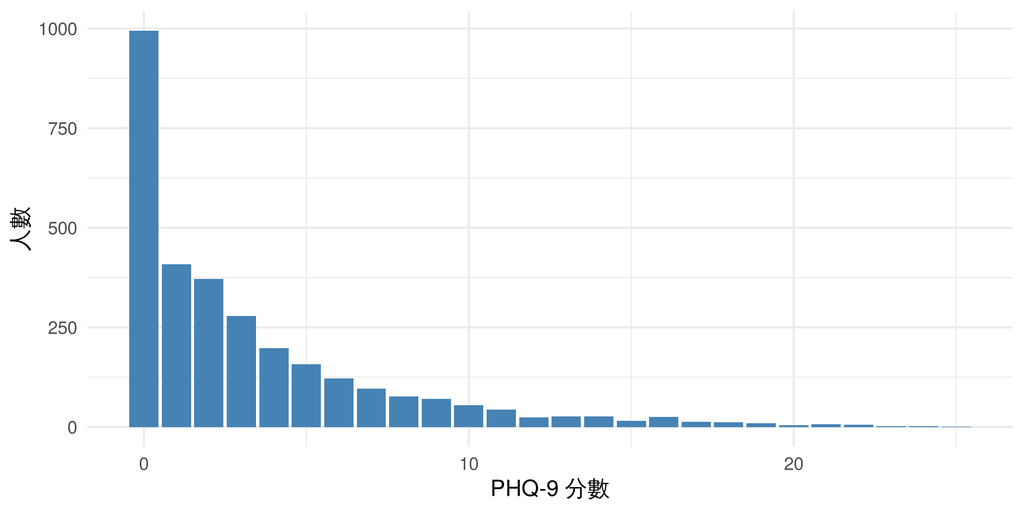

Figure 1: PHQ-9 分數的分佈

```r
ggplot(dat, aes(x = phq9_score)) +
  geom_bar(fill = "steelblue") +
  labs(x = "PHQ-9 分數", y = "人數")
```

PHQ-9 是 0 到 25 的整數（理論上限 27），強烈右偏（Table 3、Figure 1）：中位數 2、平均 3.27，有 994 人（32.7%）為 0 分。整體變異數（17.63）約為平均數的 5.4 倍，而同平均數的 Poisson 分佈只預期約 3.8% 為 0。這是**未調整解釋變數**的初步跡象，提示 Poisson 的「平均數等於變異數」假設可能不成立；正式判斷要在配適模型後檢查。

## 2.3 連續解釋變數與 PHQ-9

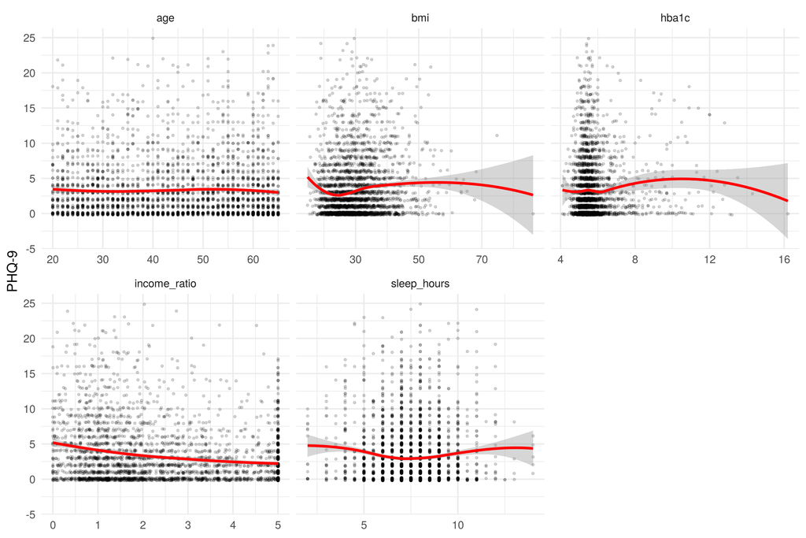

Figure 2: 連續解釋變數與 PHQ-9（紅線為 loess 平滑線）

```r
long <- pivot_longer(dat[c(num_vars, "phq9_score")], all_of(num_vars))
ggplot(long, aes(value, phq9_score)) +
  geom_jitter(alpha = .15, size = .6, height = .2) +
  geom_smooth(method = "loess", color = "red") +
  facet_wrap(~name, scales = "free_x") +
  labs(x = NULL, y = "PHQ-9")
```

```r
kable(round(cor(dat[c(num_vars, "phq9_score")]), 2))
```

Table 4: 連續變數之間的相關係數

|  | age | income_ratio | bmi | hba1c | sleep_hours | phq9_score |
| --- | --- | --- | --- | --- | --- | --- |
| age | 1.00 | 0.09 | 0.06 | 0.32 | -0.07 | 0.00 |
| income_ratio | 0.09 | 1.00 | -0.07 | -0.03 | -0.09 | -0.20 |
| bmi | 0.06 | -0.07 | 1.00 | 0.20 | -0.05 | 0.11 |
| hba1c | 0.32 | -0.03 | 0.20 | 1.00 | -0.05 | 0.05 |
| sleep_hours | -0.07 | -0.09 | -0.05 | -0.05 | 1.00 | -0.01 |
| phq9_score | 0.00 | -0.20 | 0.11 | 0.05 | -0.01 | 1.00 |

由 Figure 2 與 Table 4：income_ratio 越高，PHQ-9 傾向越低（r = −0.20）；bmi 有微弱正相關（0.11）；age 與 sleep_hours 幾乎沒有線性相關，但 sleep_hours 的平滑線呈現中間低、兩端略高的 U 形。bmi 與 hba1c 在極端值區段的平滑線資料點很少、信賴帶很寬，不宜解讀。連續解釋變數之間的相關都不高（最高為 hba1c 與 age 的 0.32），初步看不出嚴重共線性。

## 2.4 類別解釋變數與 PHQ-9

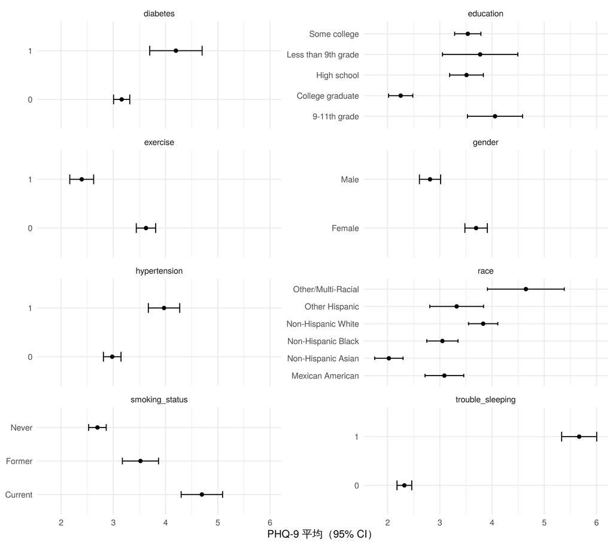

Figure 3: 各組 PHQ-9 平均與 95% 信賴區間（未調整其他變數）

```r
cl <- do.call(rbind, lapply(cat_vars, function(v)
  data.frame(var = v, level = as.character(dat[[v]]), y = dat$phq9_score)))
s <- cl %>% group_by(var, level) %>%
  summarise(m = mean(y), se = sd(y) / sqrt(n()), .groups = "drop")
ggplot(s, aes(m, level)) +
  geom_point() +
  geom_errorbarh(aes(xmin = m - 1.96 * se, xmax = m + 1.96 * se), height = .2) +
  facet_wrap(~var, scales = "free_y", ncol = 2) +
  labs(x = "PHQ-9 平均（95% CI）", y = NULL)
```

未調整其他變數時（Figure 3），差距最大的是 trouble_sleeping：有睡眠困擾者平均 5.67，無者 2.32。女性、目前吸菸者、無運動者、有糖尿病或高血壓者的平均較高；大學畢業與 Non-Hispanic Asian 的平均較低。這些是粗略比較，彼此可能互相混雜，要看模型調整後的結果。

## 2.5 資料檢查（最大值、最小值與類別）

```r
rng <- data.frame(
  變數 = c(num_vars, "phq9_score"),
  最小值 = sapply(dat[c(num_vars, "phq9_score")], min),
  中位數 = sapply(dat[c(num_vars, "phq9_score")], median),
  平均 = sapply(dat[c(num_vars, "phq9_score")], mean),
  最大值 = sapply(dat[c(num_vars, "phq9_score")], max),
  row.names = NULL
)
kable(rng, digits = 2)
```

Table 5: 數值變數的範圍

| 變數 | 最小值 | 中位數 | 平均 | 最大值 |
| --- | --- | --- | --- | --- |
| age | 20.0 | 45.0 | 44.13 | 65.0 |
| income_ratio | 0.0 | 2.2 | 2.59 | 5.0 |
| bmi | 14.8 | 28.8 | 30.07 | 86.2 |
| hba1c | 4.1 | 5.5 | 5.76 | 16.2 |
| sleep_hours | 2.0 | 7.5 | 7.45 | 14.0 |
| phq9_score | 0.0 | 2.0 | 3.27 | 25.0 |

```r
for (v in cat_vars) { cat(v, "\n"); print(table(dat[[v]])) }
```

```
gender

Female   Male
  1594   1450
race

Non-Hispanic White Non-Hispanic Black Non-Hispanic Asian   Mexican American
               995                693                454                447
    Other Hispanic Other/Multi-Racial
               279                176
education

Less than 9th grade        9-11th grade         High school        Some college
                180                 317                 728                1053
   College graduate
                766
smoking_status

  Never  Former Current
   1802     614     628
diabetes

   0    1
2707  337
exercise

   0    1
2177  867
hypertension

   0    1
2137  907
trouble_sleeping

   0    1
2177  867
```

```r
c(income_ratio等於5 = sum(dat$income_ratio == 5), bmi大於等於60 = sum(dat$bmi >= 60))
```

```
income_ratio等於5     bmi大於等於60
              573                12
```

檢查結果（Table 5）：類別名稱一致、二元變數只有 0/1、PHQ-9 落在量表範圍內。值得留意的有三點，經使用者確認後**全部保留為真實值**：

- income_ratio = 5 有 573 人（18.8%），應為 NHANES 對 ≥ 5 的截頂編碼，這群人的實際收入比可能更高，income_ratio 在高端的係數因此可能被稀釋。
- bmi ≥ 60 有 12 人（最高 86.2），罕見但生理上可能。
- hba1c 最高 16.2，可出現在血糖控制不佳的糖尿病者。

# 3 適合性評估：選擇分佈家族與連結函數

**資料結構**

- **觀測相依（群聚）**：資料來自 30 個 cluster（每群 60–146 人）。未調整時各群 PHQ-9 平均從 2.2 到 4.6，群間差異顯著。一般 GLM 假設觀測值彼此獨立，群聚會讓標準誤偏小、p 值偏樂觀。正式處理需要 GLMM 或 GEE，超出本次分析範圍；依使用者決定，以一般 GLM 分析，並在診斷時檢查殘差是否仍有群聚差異（Section 5.4.5）。
- **暴露量（offset）**：每個人的 PHQ-9 都是同一份量表、同一回憶期間（過去兩週），不需要 offset。
- **樣本數**：3,044 筆，模型約 22 個迴歸係數，樣本數充足。

**反應變數型態與起始模型**

PHQ-9 是非負整數，因此先以 **Poisson 分佈、log 連結函數（link function）** 配適 m1，係數取 exp 後為率比（rate ratio, RR），即在其他變數固定下，平均 PHQ-9 的倍數差異。

需要先說明一個限制：PHQ-9 不是「事件次數」，而是 9 題（每題 0–3 分）加總而成、有上限 27 分的量表分數。計數模型是常見而實用的近似，但它不會反映量表的上限與題目結構。本資料最高分為 25、20 分以上只有 22 人，上限造成的影響預期很小。

Poisson 假設「給定解釋變數後，條件平均數等於條件變異數」。EDA 中整體變異數遠大於平均數只是初步跡象，可能部分來自解釋變數造成的平均數差異，所以這只是起點，要在配適後以診斷確認。

# 4 模型配適

## 4.1 起始模型 m1（Poisson）

```r
f <- phq9_score ~ age + gender + race + education + income_ratio + diabetes + bmi +
  hba1c + exercise + smoking_status + hypertension + sleep_hours + trouble_sleeping
m1 <- glm(f, family = poisson(link = "log"), data = dat)

# 估計是否成功：收斂、係數與標準誤是否極端、實際使用的觀測數
check_fit <- function(m) {
  co <- summary(m)$coefficients
  data.frame(收斂 = isTRUE(m$converged), 觀測數 = nobs(m),
             最大絕對係數 = max(abs(co[, 1])), 最大標準誤 = max(co[, 2]),
             最小擬合值 = min(fitted(m)), 最大擬合值 = max(fitted(m)))
}
kable(check_fit(m1), digits = 3)
```

| 收斂 | 觀測數 | 最大絕對係數 | 最大標準誤 | 最小擬合值 | 最大擬合值 |
| --- | --- | --- | --- | --- | --- |
| TRUE | 3044 | 1.686 | 0.104 | 0.84 | 12.86 |

```r
summary(m1)
```

```
Call:
glm(formula = f, family = poisson(link = "log"), data = dat)

Coefficients:
                            Estimate Std. Error z value Pr(>|z|)
(Intercept)                1.6855294  0.1043501  16.153  < 2e-16 ***
age                       -0.0075065  0.0008827  -8.505  < 2e-16 ***
genderMale                -0.2392863  0.0212597 -11.255  < 2e-16 ***
raceNon-Hispanic Black    -0.1718591  0.0279050  -6.159 7.33e-10 ***
raceNon-Hispanic Asian    -0.2219678  0.0395161  -5.617 1.94e-08 ***
raceMexican American      -0.0927640  0.0339245  -2.734  0.00625 **
raceOther Hispanic        -0.0563386  0.0380640  -1.480  0.13885
raceOther/Multi-Racial     0.1628123  0.0386425   4.213 2.52e-05 ***
education9-11th grade     -0.0419794  0.0490362  -0.856  0.39195
educationHigh school      -0.1355426  0.0460139  -2.946  0.00322 **
educationSome college     -0.1143702  0.0456502  -2.505  0.01223 *
educationCollege graduate -0.2106411  0.0520676  -4.046 5.22e-05 ***
income_ratio              -0.1056047  0.0075448 -13.997  < 2e-16 ***
diabetes                   0.0475117  0.0385353   1.233  0.21760
bmi                        0.0008986  0.0013066   0.688  0.49163
hba1c                      0.0278854  0.0113876   2.449  0.01434 *
exercise                  -0.1732641  0.0267544  -6.476 9.41e-11 ***
smoking_statusFormer       0.0821479  0.0273508   3.003  0.00267 **
smoking_statusCurrent      0.2668936  0.0258711  10.316  < 2e-16 ***
hypertension               0.1154853  0.0238065   4.851 1.23e-06 ***
sleep_hours               -0.0256546  0.0059196  -4.334 1.47e-05 ***
trouble_sleeping           0.7815353  0.0217177  35.986  < 2e-16 ***
---
Signif. codes:  0 '***' 0.001 '**' 0.01 '*' 0.05 '.' 0.1 ' ' 1

(Dispersion parameter for poisson family taken to be 1)

    Null deviance: 14441  on 3043  degrees of freedom
Residual deviance: 11352  on 3022  degrees of freedom
AIC: 17818

Number of Fisher Scoring iterations: 6
```

m1 正常收斂，使用全部 3,044 筆觀測，係數與標準誤沒有極端值，估計在數值上沒有問題。不過係數的解釋要等診斷確認模型站得住腳之後才做（見 Section 6）。

# 5 模型診斷與評估

## 5.1 m1 的過度離散檢查

```r
check_overdispersion(m1)
```

```
# Overdispersion test

       dispersion ratio =     4.288
  Pearson's Chi-Squared = 12956.851
                p-value =   < 0.001
```

```r
pear_disp <- function(m) sum(residuals(m, type = "pearson")^2) / df.residual(m)
c(Pearson離散比值 = pear_disp(m1))
```

```
Pearson離散比值
       4.287509
```

過度離散（overdispersion）是指資料的變異比模型假設的大。m1 的 Pearson 離散比值約 4.29，遠大於 Poisson 假設下的 1。`check_overdispersion()` 對 Poisson 模型用的也是 Pearson 殘差平方和，所以它和手算比值是**同一項證據**，不是兩份。

## 5.2 m1 的零值檢查

```r
p0 <- dpois(0, lambda = fitted(m1))
c(實際零分 = sum(dat$phq9_score == 0), 預期零分 = round(sum(p0), 1),
  差距的粗略標準差 = round(sqrt(sum(p0 * (1 - p0))), 1))
```

```
        實際零分         預期零分 差距的粗略標準差
           994.0            289.6             15.4
```

即使調整了解釋變數，m1 預期只有約 290 人為 0 分，實際卻有 994 人，差距約為粗略標準差的 45 倍。

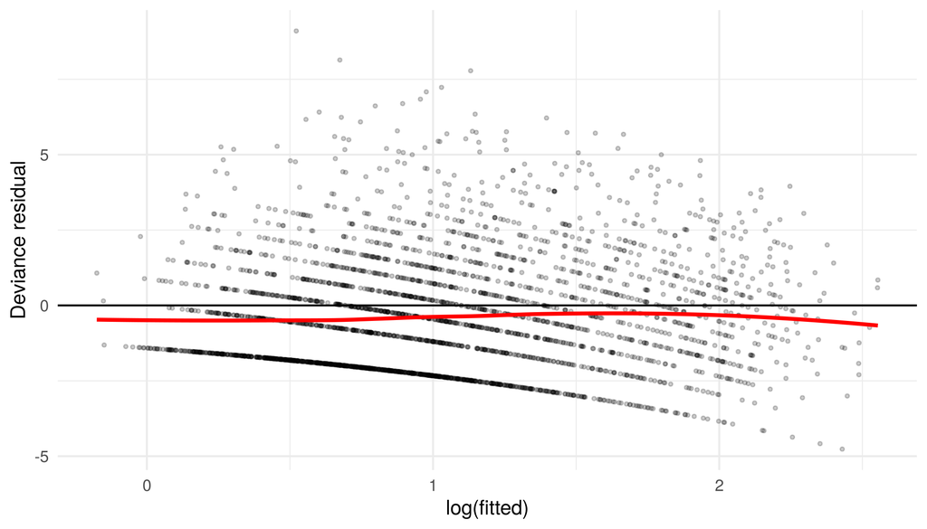

Figure 4: m1：deviance residuals 對 log(fitted)

```r
dd1 <- data.frame(fitted = fitted(m1), rd = residuals(m1, type = "deviance"))
ggplot(dd1, aes(log(fitted), rd)) +
  geom_point(alpha = .2, size = .7) + geom_hline(yintercept = 0) +
  geom_smooth(method = "loess", se = FALSE, color = "red") +
  labs(x = "log(fitted)", y = "Deviance residual")
```

Figure 4 中，平滑線大致水平，沒有明顯的系統性曲線，但殘差範圍很大（約 −5 到 +9），許多正殘差超過 3。斜向的條帶是計數資料的正常現象（每條對應一個實際分數）。

**判讀**：平均數結構沒有看到明顯錯置，但變異遠大於 Poisson 的假設，零分也嚴重不足。可能的原因包括：資料本身的條件變異大於平均數、未測量的個體差異（例如其他心理社會因素）、或零分有不同的產生機制。在 Poisson 下標準誤會被嚴重低估，因此需要調整模型。

## 5.3 調整為負二項模型 m2

`quasipoisson` 只放大標準誤、不改變對分佈形狀（包括零值比例）的描述，而且沒有概似函數，無法用 AIC 比較。負二項迴歸（negative binomial regression）以額外的離散參數 $\theta$ 讓條件變異數為 $\mu + \mu^2/\theta$，允許變異隨平均數更快增加，也會預期較多的 0。因此以 `MASS::glm.nb()` 配適 m2，平均數結構與 m1 相同。

```r
m2 <- glm.nb(f, data = dat)
kable(check_fit(m2), digits = 3)
```

| 收斂 | 觀測數 | 最大絕對係數 | 最大標準誤 | 最小擬合值 | 最大擬合值 |
| --- | --- | --- | --- | --- | --- |
| TRUE | 3044 | 1.753 | 0.245 | 0.794 | 15.026 |

```r
c(theta = m2$theta, theta的標準誤 = m2$SE.theta)
```

```
        theta theta的標準誤
    0.8848181     0.0350017
```

m2 正常收斂，$\theta$ 估計約 0.88（標準誤 0.035）。

```r
cands <- list(m1 = m1, m2 = m2)
kable(data.frame(
  模型 = c("m1 Poisson", "m2 負二項"),
  觀測數 = sapply(cands, nobs), # 比較模型必須使用相同的分析樣本
  迴歸係數個數 = sapply(cands, function(m) length(coef(m))),
  額外分布參數 = c(0, 1),
  AIC = sapply(cands, AIC),
  BIC = sapply(cands, BIC),
  Pearson離散比值 = sapply(cands, pear_disp),
  row.names = NULL
), digits = 2)
# Poisson 是負二項在 1/theta = 0 時的邊界情形，概似比檢定的 p 值用混合卡方（一半的卡方 1 自由度）
lr <- as.numeric(2 * (logLik(m2) - logLik(m1)))
c(LR統計量 = lr, p值 = 0.5 * pchisq(lr, 1, lower.tail = FALSE))
```

```
LR統計量      p值
4342.181    0.000
```

Table 6: m1（Poisson）與 m2（負二項）的比較

| 模型 | 觀測數 | 迴歸係數個數 | 額外分布參數 | AIC | BIC | Pearson離散比值 |
| --- | --- | --- | --- | --- | --- | --- |
| m1 Poisson | 3044 | 22 | 0 | 17817.57 | 17950.03 | 4.29 |
| m2 負二項 | 3044 | 22 | 1 | 13477.39 | 13615.87 | 1.07 |

兩個模型使用相同的 3,044 筆觀測（Table 6）。m2 的 AIC 比 m1 低約 4,340，BIC 也大幅降低；概似比檢定（likelihood ratio test, LRT）的統計量約 4,342，p 值極小（因 Poisson 位於參數空間邊界，使用一半卡方分布的修正）。m2 的 Pearson 離散比值降到約 1.07。

需要說明的是：$\theta$ 是用同一批資料估計、專門用來吸收多出的變異，所以離散比值降到接近 1 **並不意外**，不是「m2 已正確」的獨立證據。以下用殘差、零值與其他檢查一起判讀 m2。

## 5.4 m2 的診斷

### 5.4.1 離散程度

```r
check_overdispersion(m2)
```

```
# Overdispersion test

       dispersion ratio =    1.067
  Pearson's Chi-Squared = 3225.085
                p-value =    0.005
```

m2 的 Pearson 離散比值約 1.07，`check_overdispersion()` 仍以 p = 0.005 標示為過度離散。這項檢定用的是同一個 Pearson 統計量，且自由度採用 `df.residual`（不會因估計 $\theta$ 而調整），$\theta$ 的估計不確定性也會影響卡方近似，所以只當粗略參考：殘餘的額外變異幅度約 7%，量不大，但與下面的零值檢查一致，提示 m2 仍未完全描述資料的分佈形狀。

### 5.4.2 零值與預期次數分佈

```r
k <- 0:10
obs <- sapply(k, function(i) sum(dat$phq9_score == i))
exp_nb <- sapply(k, function(i) sum(dnbinom(i, mu = fitted(m2), size = m2$theta)))
exp_p <- sapply(k, function(i) sum(dpois(i, fitted(m1))))
kable(data.frame(PHQ9 = k, 實際 = obs, m2負二項預期 = exp_nb, m1Poisson預期 = exp_p,
                 row.names = NULL), digits = 1)
p0b <- dnbinom(0, mu = fitted(m2), size = m2$theta)
c(實際零分 = sum(dat$phq9_score == 0), 預期零分 = round(sum(p0b), 1),
  差距 = round(sum(dat$phq9_score == 0) - sum(p0b), 1),
  差距的粗略標準差 = round(sqrt(sum(p0b * (1 - p0b))), 1))
```

```
        實際零分         預期零分             差距 差距的粗略標準差
           994.0            897.7             96.3             24.5
```

Table 7: 實際人數與模型預期人數（PHQ-9 = 0 到 10）

| PHQ9 | 實際 | m2負二項預期 | m1Poisson預期 |
| --- | --- | --- | --- |
| 0 | 994 | 897.7 | 289.6 |
| 1 | 408 | 567.0 | 551.8 |
| 2 | 371 | 387.8 | 594.9 |
| 3 | 278 | 275.0 | 491.6 |
| 4 | 198 | 199.9 | 355.9 |
| 5 | 157 | 148.3 | 244.2 |
| 6 | 122 | 111.9 | 166.1 |
| 7 | 96 | 85.8 | 114.1 |
| 8 | 77 | 66.7 | 79.0 |
| 9 | 71 | 52.4 | 54.5 |
| 10 | 55 | 41.7 | 37.0 |

m2 對整體分佈的描述遠比 m1 接近實際（Table 7），2 分以上大致吻合。但仍有兩個落差：實際 0 分 994 人，m2 預期約 898 人，差約 96 人（約 4 倍粗略標準差；這個標準差未計入係數估計的不確定性，只是粗略參考）；1 分則是實際 408 人、預期約 567 人，m2 高估。也就是說，資料中「完全沒有症狀」與「有一點症狀」之間的落差比負二項描述的更明顯。

**可能的解釋**（不能直接判定為零膨脹）：

- 平均數結構仍有遺漏，例如未測量的心理社會因素，或 sleep_hours 等變數的非線性關係（見下方殘差圖）。
- PHQ-9 是題目加總的量表，0 分代表 9 題都回答「完全沒有」，其產生方式不同於一般的計數過程。
- 群聚或其他未建模的異質性。

若上述因素都處理後 0 分仍明顯偏多，可以考慮兩類延伸模型，兩者機制不同：

- **零膨脹模型（zero-inflated model）**：假設 0 有兩種來源，一種是結構性的 0（例如本來就沒有憂鬱症狀傾向的人），另一種是有症狀傾向、但這段期間剛好沒有症狀的 0。
- **門檻模型（hurdle model）**：分兩階段，先決定「是否有任何症狀（0 或大於 0）」，再以排除 0 的截斷分佈描述有症狀者的分數高低。

選擇哪一種要依資料的產生機制，不能只看 AIC。**本分析流程不支援這兩類模型的配適與解釋**，如需進一步分析，請使用專門的工具（例如 R 的 `pscl` 或 `glmmTMB` 套件）。

### 5.4.3 殘差對 fitted values

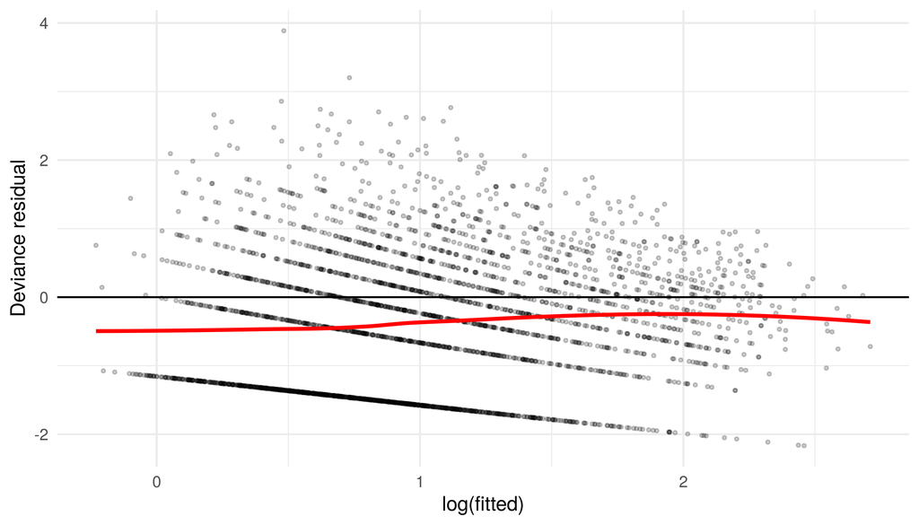

Figure 5: m2：deviance residuals 對 log(fitted)

```r
dd2 <- data.frame(fitted = fitted(m2), rd = residuals(m2, type = "deviance"))
ggplot(dd2, aes(log(fitted), rd)) +
  geom_point(alpha = .2, size = .7) + geom_hline(yintercept = 0) +
  geom_smooth(method = "loess", se = FALSE, color = "red") +
  labs(x = "log(fitted)", y = "Deviance residual")
```

Figure 5 的殘差範圍縮小到約 −2 到 +4，平滑線大致水平，隨 fitted 值只有輕微上升，沒有明顯的系統性曲線。平滑線整體略低於 0，是右偏計數資料 deviance residuals 常見的現象（中位數小於 0），不代表平均數有偏誤。最下方那條明顯的條帶就是 0 分的觀測。

### 5.4.4 殘差對連續解釋變數

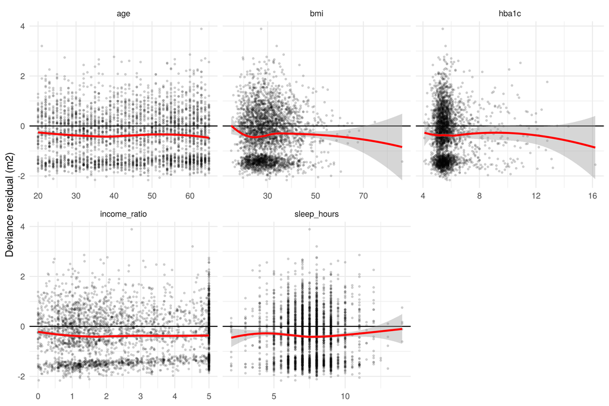

Figure 6: m2：deviance residuals 對各連續解釋變數（紅線為 loess）

```r
d <- dat[num_vars]
d$rd <- residuals(m2, type = "deviance")
ggplot(pivot_longer(d, all_of(num_vars)), aes(value, rd)) +
  geom_point(alpha = .15, size = .6) + geom_hline(yintercept = 0) +
  geom_smooth(method = "loess", color = "red") +
  facet_wrap(~name, scales = "free_x") +
  labs(x = NULL, y = "Deviance residual (m2)")
```

Figure 6 中，age 與 income_ratio 的平滑線大致水平，線性形式看起來合理。另外幾個變數有輕微的形狀：

- **sleep_hours**：平滑線在 7–8 小時附近最低，往兩端（尤其 10 小時以上）略為上升，與 EDA 看到的 U 形一致。模型只放了線性項，可能**沒有完整捕捉**睡太少與睡太多都與較高 PHQ-9 有關的型態；sleep_hours 的線性係數因此只是一個平均斜率的摘要。
- **bmi**：BMI 低於約 20 的區段平滑線較高，往後大致平坦；BMI 60 以上點很少，信賴帶很寬。
- **hba1c**：12 以上點很少，平滑線下彎但信賴帶很寬，不宜解讀。

依本分析流程，這裡只描述，不自動加入非線性項；後續若要深入，可以考慮對 sleep_hours（與 bmi）改用樣條（spline）等非線性形式。

### 5.4.5 群聚相依性

```r
anova(lm(rd ~ cluster_id, data = cbind(dat, rd = residuals(m2, type = "deviance"))))
```

```
Analysis of Variance Table

Response: rd
             Df  Sum Sq Mean Sq F value Pr(>F)
cluster_id   29   29.97 1.03360  1.0682 0.3674
Residuals  3014 2916.27 0.96757
```

調整解釋變數之後，各 cluster 的平均殘差沒有顯著差異（F 檢定 p = 0.37）。原本 EDA 看到的群間差異，大部分可由各群人口組成的差異說明。這降低了「群聚嚴重違反獨立性」的疑慮，但**不能證明觀測彼此獨立**：檢定只看群平均，檢定力有限，而且 NHANES 屬於複雜抽樣設計，本分析也沒有使用抽樣權重。依使用者決定，本報告的標準誤未對群聚做修正，p 值可能略偏樂觀，結果也不能直接推論到美國全體人口。

### 5.4.6 共線性

```r
vif(m2)
```

```
                     GVIF Df GVIF^(1/(2*Df))
age              1.394449  1        1.180868
gender           1.086472  1        1.042340
race             1.533631  5        1.043691
education        1.750504  4        1.072495
income_ratio     1.403849  1        1.184841
diabetes         1.709672  1        1.307544
bmi              1.173558  1        1.083309
hba1c            1.760495  1        1.326836
exercise         1.191068  1        1.091361
smoking_status   1.282511  2        1.064180
hypertension     1.287714  1        1.134775
sleep_hours      1.035969  1        1.017826
trouble_sleeping 1.139519  1        1.067483
```

所有變數的 `GVIF^(1/(2*Df))` 都在 1.02 到 1.33 之間（平方後約 1.0 到 1.8），沒有共線性警示。即使是概念重疊的 diabetes 與 hba1c，GVIF 也只有約 1.7 到 1.8。不過兩者的單獨係數仍要合併解讀（見 Section 6）。

### 5.4.7 診斷總覽圖

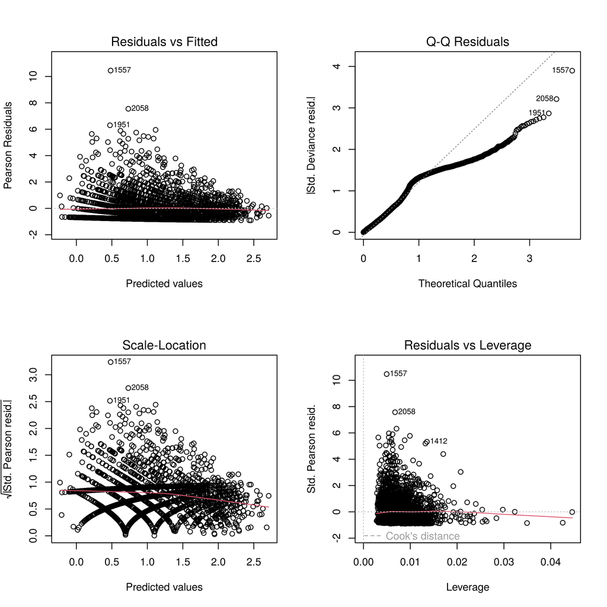

Figure 7: m2 的 base R 四合一診斷圖

```r
par(mfrow = c(2, 2))
plot(m2)
```

Figure 7 的判讀：

- **Residuals vs Fitted**：Pearson 殘差呈斜向條帶（計數資料的正常現象），紅線大致貼近 0；有幾個大的正殘差（標註 1557、2058、1951），是 PHQ-9 分數遠高於預期的人。
- **Q-Q 圖**：GLM 不要求殘差服從常態，這張圖不用來判斷常態性。圖中呈現分段的形狀，是離散資料（尤其大量 0 分）造成的，只用來確認沒有個別極端異常點，最大的幾個點同上。
- **Scale-Location**：呈現計數資料典型的弧形條帶，紅線隨預測值略降，不套用線性迴歸的等變異標準解讀。
- **Residuals vs Leverage**：最大槓桿值約 0.045，沒有點接近 Cook’s distance 的警示線，沒有單一觀測對估計有過大的影響。

### 5.4.8 適合度檢定

以 deviance 或 Pearson 卡方做整體適合度檢定，需要每個觀測的預期次數不能太小，本資料許多人的預期 PHQ-9 只有 1–2 分，加上 $\theta$ 是估計值，卡方近似不可靠，因此**不把它當正式檢定**，改以 Table 7 的預期次數分佈比較作為整體配適的主要證據。

```r
r2(m2)
```

```
# R2 for Generalized Linear Regression
  Nagelkerke's R2: 0.263
```

m2 的 Nagelkerke pseudo-$R^2$ 為 0.263。這是**樣本內**的指標，通常比樣本外表現樂觀，而且不能像線性迴歸的 $R^2$ 那樣解讀成「解釋變異的比例」。

## 5.5 診斷完成紀錄

```r
kable(data.frame(
  檢查項目 = c("估計是否成功（收斂、極端係數）", "過度離散（m1）", "過度離散（m2）",
           "零值與預期次數分佈", "殘差對 fitted", "殘差對連續解釋變數",
           "群聚相依性", "共線性（GVIF）", "四合一總覽圖",
           "卡方適合度檢定", "DHARMa 模擬殘差", "樣本外預測評估"),
  狀態 = c("已執行，結果可判讀", "已執行，結果可判讀", "已執行，結果受限",
         "已執行，結果可判讀", "已執行，結果可判讀", "已執行，結果可判讀",
         "已執行，結果受限", "已執行，結果可判讀", "已執行，結果可判讀",
         "不適用，已跳過", "無法執行", "不適用，已跳過"),
  結果摘要或原因 = c(
    "m1、m2 皆收斂，n = 3044，無極端值",
    "離散比值約 4.29，明顯過度離散，改用負二項",
    "離散比值約 1.07；檢定自由度未考慮 theta 的估計，只當粗略參考",
    "m2 仍低估 0 分（994 vs 約 898）、高估 1 分（408 vs 約 567）",
    "m2 平滑線大致水平，無明顯系統性曲線",
    "sleep_hours 有輕微 U 形、低 BMI 端略高；只描述，未加入非線性項",
    "調整後各群平均殘差無顯著差異（p = 0.37），但無法證明獨立；標準誤未修正",
    "所有 GVIF^(1/(2Df)) 介於 1.02 與 1.33",
    "無高槓桿或高影響點；少數大的正殘差",
    "預期次數小且 theta 為估計值，卡方近似不可靠；改用預期次數分佈比較",
    "環境無法安裝 DHARMa 套件",
    "研究目的為解釋關聯，使用者未要求驗證預測表現"),
  row.names = NULL
))
```

Table 8: 診斷項目完成紀錄

| 檢查項目 | 狀態 | 結果摘要或原因 |
| --- | --- | --- |
| 估計是否成功（收斂、極端係數） | 已執行，結果可判讀 | m1、m2 皆收斂，n = 3044，無極端值 |
| 過度離散（m1） | 已執行，結果可判讀 | 離散比值約 4.29，明顯過度離散，改用負二項 |
| 過度離散（m2） | 已執行，結果受限 | 離散比值約 1.07；檢定自由度未考慮 theta 的估計，只當粗略參考 |
| 零值與預期次數分佈 | 已執行，結果可判讀 | m2 仍低估 0 分（994 vs 約 898）、高估 1 分（408 vs 約 567） |
| 殘差對 fitted | 已執行，結果可判讀 | m2 平滑線大致水平，無明顯系統性曲線 |
| 殘差對連續解釋變數 | 已執行，結果可判讀 | sleep_hours 有輕微 U 形、低 BMI 端略高；只描述，未加入非線性項 |
| 群聚相依性 | 已執行，結果受限 | 調整後各群平均殘差無顯著差異（p = 0.37），但無法證明獨立；標準誤未修正 |
| 共線性（GVIF） | 已執行，結果可判讀 | 所有 GVIF^(1/(2Df)) 介於 1.02 與 1.33 |
| 四合一總覽圖 | 已執行，結果可判讀 | 無高槓桿或高影響點；少數大的正殘差 |
| 卡方適合度檢定 | 不適用，已跳過 | 預期次數小且 theta 為估計值，卡方近似不可靠；改用預期次數分佈比較 |
| DHARMa 模擬殘差 | 無法執行 | 環境無法安裝 DHARMa 套件 |
| 樣本外預測評估 | 不適用，已跳過 | 研究目的為解釋關聯，使用者未要求驗證預測表現 |

## 5.6 最終模型確認

**最終模型為 m2（負二項迴歸，log link）**。過程為：m1（Poisson）→ 診斷發現嚴重過度離散（離散比值約 4.29）與零分嚴重不足 → 調整為 m2（負二項），平均數結構不變 → m2 的 AIC、BIC 大幅降低，邊界修正的概似比檢定極顯著，殘差範圍縮小且無系統性型態 → 確認 m2。

m2 仍有兩項限制：0 分略多於預期、1 分少於預期，以及 sleep_hours 可能有未捕捉的非線性。這些不影響「m2 比 m1 合理得多」的結論，但代表 m2 不是對資料的完整描述，下面的係數要在這個前提下解讀。

# 6 最終模型 m2 的係數解釋

```r
ci <- exp(confint(m2)) # profile likelihood 信賴區間
co <- summary(m2)$coefficients
coef_tbl <- data.frame(
  變數 = rownames(co),
  率比RR = exp(co[, 1]),
  CI下限 = ci[, 1],
  CI上限 = ci[, 2],
  p值 = format.pval(co[, 4], digits = 2, eps = 1e-4),
  row.names = NULL
)
kable(coef_tbl, digits = c(0, 3, 3, 3, 4))
```

Table 9: 最終模型 m2 的率比（rate ratio）與 95% 信賴區間（profile likelihood）

| 變數 | 率比RR | CI下限 | CI上限 | p值 |
| --- | --- | --- | --- | --- |
| (Intercept) | 5.769 | 3.557 | 9.363 | <1e-04 |
| age | 0.991 | 0.987 | 0.995 | <1e-04 |
| genderMale | 0.760 | 0.694 | 0.833 | <1e-04 |
| raceNon-Hispanic Black | 0.822 | 0.728 | 0.929 | 0.0017 |
| raceNon-Hispanic Asian | 0.808 | 0.694 | 0.941 | 0.0059 |
| raceMexican American | 0.887 | 0.767 | 1.028 | 0.1112 |
| raceOther Hispanic | 0.903 | 0.764 | 1.071 | 0.2366 |
| raceOther/Multi-Racial | 1.205 | 0.998 | 1.462 | 0.0550 |
| education9-11th grade | 0.925 | 0.736 | 1.160 | 0.5015 |
| educationHigh school | 0.856 | 0.692 | 1.054 | 0.1428 |
| educationSome college | 0.872 | 0.708 | 1.071 | 0.1967 |
| educationCollege graduate | 0.767 | 0.610 | 0.962 | 0.0224 |
| income_ratio | 0.898 | 0.871 | 0.927 | <1e-04 |
| diabetes | 1.091 | 0.912 | 1.307 | 0.3392 |
| bmi | 1.000 | 0.994 | 1.006 | 0.9958 |
| hba1c | 1.047 | 0.992 | 1.106 | 0.0899 |
| exercise | 0.846 | 0.759 | 0.943 | 0.0024 |
| smoking_statusFormer | 1.063 | 0.944 | 1.199 | 0.3103 |
| smoking_statusCurrent | 1.320 | 1.173 | 1.487 | <1e-04 |
| hypertension | 1.104 | 0.992 | 1.230 | 0.0699 |
| sleep_hours | 0.972 | 0.946 | 0.998 | 0.0397 |
| trouble_sleeping | 2.250 | 2.039 | 2.486 | <1e-04 |

```r
terms_x <- attr(terms(f), "term.labels")
ov <- do.call(rbind, lapply(terms_x, function(t) {
  mr <- glm.nb(update(f, paste(". ~ . -", t)), data = dat)
  a <- anova(mr, m2)
  data.frame(變數 = t, 自由度 = a[["   df"]][2], LR統計量 = a[["LR stat."]][2],
             p值 = format.pval(a[["Pr(Chi)"]][2], digits = 2, eps = 1e-4))
}))
kable(ov, digits = c(0, 0, 2, 4), row.names = FALSE)
```

Table 10: 各變數的整體檢定（拿掉該項後以 glm.nb 重配、theta 各自估計，概似比檢定）

| 變數 | 自由度 | LR統計量 | p值 |
| --- | --- | --- | --- |
| age | 1 | 22.22 | <1e-04 |
| gender | 1 | 34.47 | <1e-04 |
| race | 5 | 22.93 | 0.00035 |
| education | 4 | 7.09 | 0.13 |
| income_ratio | 1 | 44.88 | <1e-04 |
| diabetes | 1 | 0.89 | 0.34 |
| bmi | 1 | 0.00 | 1 |
| hba1c | 1 | 2.77 | 0.096 |
| exercise | 1 | 9.09 | 0.0026 |
| smoking_status | 2 | 21.52 | <1e-04 |
| hypertension | 1 | 3.27 | 0.071 |
| sleep_hours | 1 | 4.40 | 0.036 |
| trouble_sleeping | 1 | 254.69 | <1e-04 |

```r
# diabetes 與 hba1c 的聯合檢定
m2_nodm <- glm.nb(update(f, . ~ . - diabetes - hba1c), data = dat)
anova(m2_nodm, m2)
```

```
Likelihood ratio tests of Negative Binomial Models

Response: phq9_score
                                                                                                                                                Model
1                    age + gender + race + education + income_ratio + bmi + exercise + smoking_status + hypertension + sleep_hours + trouble_sleeping
2 age + gender + race + education + income_ratio + diabetes + bmi + hba1c + exercise + smoking_status + hypertension + sleep_hours + trouble_sleeping
      theta Resid. df    2 x log-lik.   Test    df LR stat.    Pr(Chi)
1 0.8815577      3024       -13439.52
2 0.8848181      3022       -13431.39 1 vs 2     2 8.129853 0.01716425
```

率比（RR）的意思是：在其他變數固定下，平均 PHQ-9 分數的倍數差異；RR = 1.25 代表平均分數高 25%，RR = 0.80 代表低 20%。以下都是關聯，不代表因果。

**與較高 PHQ-9 有關聯的變數**

- **trouble_sleeping**：有睡眠困擾者的平均 PHQ-9 約為無睡眠困擾者的 2.25 倍（95% CI 2.04–2.49），是模型中關聯最強的變數。但如前所述，PHQ-9 本身就包含睡眠題，這個數字有一部分是量表題目的重疊，不能全部解讀為睡眠困擾與憂鬱的關聯。
- **smoking_status**（整體 p < 0.001）：目前吸菸者比從未吸菸者高約 32%（RR 1.32，95% CI 1.17–1.49）。Tukey 校正的兩兩比較顯示目前吸菸者也高於曾吸菸者（Table 13）；曾吸菸者與從未吸菸者之間，資料無法區分（RR 1.06，95% CI 0.94–1.20）。

**與較低 PHQ-9 有關聯的變數**

- **income_ratio**：收入貧窮比每增加 1，平均 PHQ-9 低約 10%（RR 0.90，95% CI 0.87–0.93）。由於約 19% 的人被截頂在 5，高收入端的關聯可能被低估。
- **gender**：男性比女性低約 24%（RR 0.76，95% CI 0.69–0.83）。
- **age**：每增加 10 歲，平均 PHQ-9 低約 9%（RR 0.91，95% CI 0.88–0.95）。這是調整其他變數後的結果，與 EDA 中未調整時幾乎沒有相關不同，可能因為年齡較大者較常有糖尿病、高血壓等與較高 PHQ-9 相關的狀況，調整後才顯現。
- **exercise**：有運動者低約 15%（RR 0.85，95% CI 0.76–0.94）。
- **sleep_hours**：每多睡 1 小時，平均 PHQ-9 低約 3%（RR 0.97，95% CI 0.95–1.00，p = 0.04）。但殘差圖提示可能是 U 形關係，這個線性係數只是平均斜率，不宜解讀為「睡越多越好」。
- **race**（整體 p < 0.001）：與 Non-Hispanic White 相比，Non-Hispanic Black 低約 18%（RR 0.82，95% CI 0.73–0.93）、Non-Hispanic Asian 低約 19%（RR 0.81，95% CI 0.69–0.94）。Tukey 校正的兩兩比較（Table 11）中，有顯著差異的是：Non-Hispanic White 高於 Non-Hispanic Black，以及 Other/Multi-Racial 高於 Non-Hispanic Black 與 Non-Hispanic Asian；其餘配對資料無法區分。

**資料無法區分的變數**

- **education**（整體 p = 0.13）：College graduate 對 Less than 9th grade 的單一係數 p = 0.02（RR 0.77，95% CI 0.61–0.96），但教育的整體檢定不顯著，Tukey 校正後所有兩兩比較也都不顯著（最小校正 p = 0.15）。整體而言，在調整收入等變數後，資料無法區分不同教育程度的 PHQ-9 差異。EDA 中大學畢業者的平均較低，可能有一部分與收入重疊。
- **diabetes 與 hba1c**：兩者單獨都不顯著（diabetes RR 1.09，95% CI 0.91–1.31；hba1c 每增加 1 個百分點 RR 1.05，95% CI 0.99–1.11），但**聯合檢定顯著**（p = 0.017）。兩者都在描述血糖狀態，放在同一模型中會互相分攤關聯，所以單獨看都不顯著。合理的解讀是：血糖狀態整體上與較高 PHQ-9 有關聯，但資料無法分辨是「有糖尿病診斷」還是「HbA1c 數值」本身的關聯。
- **hypertension**：RR 1.10（95% CI 0.99–1.23，p = 0.07），點估計偏高，但信賴區間包含 1，資料無法區分。
- **bmi**：每增加 1 單位 RR 1.000（95% CI 0.994–1.006）。EDA 中 bmi 與 PHQ-9 有微弱正相關，調整其他變數後無法區分。信賴區間相當窄，以 BMI 增加 5 單位換算約為 0.97 到 1.03 倍。

```r
emm_r <- emmeans(m2, ~ race)
pw <- as.data.frame(confint(pairs(emm_r, adjust = "tukey"), type = "response"))
pw$p.value <- as.data.frame(pairs(emm_r, adjust = "tukey", type = "response"))$p.value
kable(pw[, c("contrast", "ratio", "asymp.LCL", "asymp.UCL", "p.value")], digits = 3, row.names = FALSE)
```

Table 11: race 的兩兩比較（m2，Tukey 校正；比值為兩組平均 PHQ-9 的倍數）

| contrast | ratio | asymp.LCL | asymp.UCL | p.value |
| --- | --- | --- | --- | --- |
| (Non-Hispanic White) / (Non-Hispanic Black) | 1.216 | 1.018 | 1.453 | 0.021 |
| (Non-Hispanic White) / (Non-Hispanic Asian) | 1.238 | 0.992 | 1.545 | 0.066 |
| (Non-Hispanic White) / Mexican American | 1.127 | 0.910 | 1.396 | 0.603 |
| (Non-Hispanic White) / Other Hispanic | 1.107 | 0.867 | 1.413 | 0.845 |
| (Non-Hispanic White) / (Other/Multi-Racial) | 0.830 | 0.630 | 1.095 | 0.391 |
| (Non-Hispanic Black) / (Non-Hispanic Asian) | 1.018 | 0.804 | 1.288 | 1.000 |
| (Non-Hispanic Black) / Mexican American | 0.927 | 0.739 | 1.162 | 0.930 |
| (Non-Hispanic Black) / Other Hispanic | 0.910 | 0.705 | 1.175 | 0.900 |
| (Non-Hispanic Black) / (Other/Multi-Racial) | 0.682 | 0.511 | 0.912 | 0.002 |
| (Non-Hispanic Asian) / Mexican American | 0.910 | 0.700 | 1.183 | 0.910 |
| (Non-Hispanic Asian) / Other Hispanic | 0.894 | 0.672 | 1.188 | 0.872 |
| (Non-Hispanic Asian) / (Other/Multi-Racial) | 0.670 | 0.487 | 0.923 | 0.005 |
| Mexican American / Other Hispanic | 0.982 | 0.750 | 1.287 | 1.000 |
| Mexican American / (Other/Multi-Racial) | 0.737 | 0.539 | 1.007 | 0.060 |
| Other Hispanic / (Other/Multi-Racial) | 0.750 | 0.537 | 1.048 | 0.140 |

```r
emm_e <- emmeans(m2, ~ education)
pw <- as.data.frame(confint(pairs(emm_e, adjust = "tukey"), type = "response"))
pw$p.value <- as.data.frame(pairs(emm_e, adjust = "tukey", type = "response"))$p.value
kable(pw[, c("contrast", "ratio", "asymp.LCL", "asymp.UCL", "p.value")], digits = 3, row.names = FALSE)
```

Table 12: education 的兩兩比較（m2，Tukey 校正）

| contrast | ratio | asymp.LCL | asymp.UCL | p.value |
| --- | --- | --- | --- | --- |
| Less than 9th grade / (9-11th grade) | 1.081 | 0.789 | 1.479 | 0.962 |
| Less than 9th grade / High school | 1.169 | 0.874 | 1.563 | 0.585 |
| Less than 9th grade / Some college | 1.146 | 0.859 | 1.530 | 0.697 |
| Less than 9th grade / College graduate | 1.303 | 0.950 | 1.789 | 0.150 |
| (9-11th grade) / High school | 1.082 | 0.864 | 1.354 | 0.875 |
| (9-11th grade) / Some college | 1.061 | 0.852 | 1.321 | 0.948 |
| (9-11th grade) / College graduate | 1.206 | 0.936 | 1.555 | 0.259 |
| High school / Some college | 0.981 | 0.833 | 1.155 | 0.998 |
| High school / College graduate | 1.115 | 0.911 | 1.364 | 0.580 |
| Some college / College graduate | 1.137 | 0.950 | 1.361 | 0.292 |

```r
emm_s <- emmeans(m2, ~ smoking_status)
pw <- as.data.frame(confint(pairs(emm_s, adjust = "tukey"), type = "response"))
pw$p.value <- as.data.frame(pairs(emm_s, adjust = "tukey", type = "response"))$p.value
kable(pw[, c("contrast", "ratio", "asymp.LCL", "asymp.UCL", "p.value")], digits = 3, row.names = FALSE)
```

Table 13: smoking_status 的兩兩比較（m2，Tukey 校正）

| contrast | ratio | asymp.LCL | asymp.UCL | p.value |
| --- | --- | --- | --- | --- |
| Never / Former | 0.940 | 0.816 | 1.084 | 0.568 |
| Never / Current | 0.758 | 0.657 | 0.873 | 0.000 |
| Former / Current | 0.806 | 0.682 | 0.951 | 0.006 |

註：係數表（Table 9）的信賴區間為 profile likelihood，兩兩比較表的信賴區間為 Wald 法（emmeans 預設）。

# 7 結論

**最終模型**：負二項迴歸（m2，log link），使用全部 3,044 筆觀測。Poisson 模型（m1）有嚴重過度離散，不適合用於推論；以下數字全部來自 m2。

**主要發現**（在其他變數固定下的關聯）：

1. 睡眠困擾與 PHQ-9 的關聯最強（平均分數約高 2.25 倍），但部分反映量表本身包含睡眠題。
2. 目前吸菸（約高 32%）與較高的 PHQ-9 有關聯；收入較高（每單位約低 10%）、男性（約低 24%）、年齡較大（每 10 歲約低 9%）、有運動（約低 15%）與較低的 PHQ-9 有關聯。
3. 種族整體上有關聯，經多重比較校正後，Non-Hispanic Black 低於 Non-Hispanic White，Other/Multi-Racial 高於 Non-Hispanic Black 與 Non-Hispanic Asian。
4. 糖尿病與 HbA1c 合併看有關聯（聯合檢定 p = 0.017），但無法分辨是哪一個；教育程度、高血壓、BMI 在調整後資料無法區分。

**限制**：

- 橫斷面資料，所有結果都是關聯，不能推論因果或先後順序；睡眠、運動、吸菸等與憂鬱症狀可能互相影響。
- m2 仍略低估 0 分、高估 1 分；sleep_hours 可能有未捕捉的非線性關係。零膨脹或門檻模型、樣條等延伸分析超出本次範圍。
- 未修正 30 個群聚的相依性，也未使用 NHANES 抽樣權重；調整後殘差未見明顯群聚差異，但標準誤仍可能略被低估，結果也不能直接推論到美國全體人口。
- income_ratio 在 5 截頂，高收入端的關聯可能被低估。
- 本分析以解釋關聯為目的，未做樣本外預測評估。模型診斷通過不等於預測能力良好；pseudo-$R^2$ 0.263 是樣本內指標，通常偏樂觀。